# The Impact of Technology Access on Earnigs

Group 06

January 28, 2019

# 0. Research Question and Variable Selection

**Research Questions:**

With a past of racial inequality in the southern states it would be interesting to examine how race/ethnicity is related to access to the internet and other technologies and how not having or having access could effect a persons earnings. This can be explored via the following research questions:

1. In the state of Alabama, how to earnings vary by access to the internet/technology?
2. Does the internet/technology premium vary by race and ethnicity?

**Variable Selection**:

To answer the research questions, this study looks at the variables which will reveal the demographic characteristics - such as “age” or “race”; socioeconomic status - such as “employment status” or “wage”; and the access to techonlogy - such as “access to internet.”

- The following variables will be included in this study. (Some other varialbes will be used as connector when joining tables but will not be included in the final dataframe.)
  1. AGEP # Age: 0#99
  2. SEMP # Self-employment income past 12 months (signed)
  3. WAGP # Wages or salary income past 12 months
  4. HISP # Recoded detailed Hispanic origin
  5. NATIVITY # Nativity
  6. PERNP # Total person’s earnings
  7. RAC1P # Recoded detailed race code
  8. RACAIAN # American Indian and Alaska Native recode
  9. RACASN # Asian recode
  10. RACBLK # Black or African American recode
  11. RACNH # Native Hawaiian recode
  12. RACWHT # White recode
  13. WAOB # World area of birth
  14. WKW #Weeks worked during past 12 months
  15. ACCESS # Access to the Internet

# 1. System Setup

The following chunk of code (hidden from this html file) are applied to clean the working environment. There libraries and one external function are loaded.

Three loaded libraries are:

1. tidyverse
2. here
3. DataExplorer

One external function was programmed by the team. It is located at folder of “code”, and the function is:

1. function_convert_CSV_to_vector.R

# 2. Data Cleaning

## 2.1 Import the raw data

Import the raw data of personal income (ss16pal) into the dataframe of “base.”

```r
#load the persional data to variable Base
base <- read_csv(here('raw_data','ss16pal.csv'))%>%
  select(SERIALNO, #Serial Number to link House Hold and Personal data
         AGEP,  # Age: 0#99
         SEMP,  # Self-employment income past 12 months (signed)
         WAGP,  # Wages or salary income past 12 months
         HISP,  # Recoded detailed Hispanic origin
         NATIVITY,  # Nativity
         PERNP, # Total person's earnings
         RAC1P, # Recoded detailed race code
         RACAIAN, # American Indian and Alaska Native recode
         RACASN,  # Asian recode
         RACBLK,  # Black or African American recode
         RACNH, # Native Hawaiian recode
         RACWHT,  # White recode
         WAOB,  # World area of birth
         WKW)   #Weeks worked during past 12 months
```

Import the household level information (ss16hal) about internet access and merge the data into “base.”

```r
#Link the house hould data
househould <- read_csv(here('raw_data','ss16hal.csv'))%>%
  select(SERIALNO, #Serial Number to link House Hold and Personal data
        ACCESS # Access to the Internet
  )
base <- base %>% left_join(househould) %>% select(-SERIALNO)
rm(househould)
```

## 2.2 Structure of raw data

Based on the first observation below, some ordinary data will be converted into numerical type, and some categorical data will be converted into factor type.

```
Classes ‘spec_tbl_df’, ‘tbl_df’, ‘tbl’ and 'data.frame':    47659 obs. of  15 variables:
 $ AGEP    : chr  "84" "84" "78" "46" ...
 $ SEMP    : chr  "0000000" "0000000" "0000000" "0000000" ...
 $ WAGP    : chr  "0000000" "0000000" "0027300" "0065000" ...
 $ HISP    : chr  "01" "01" "01" "01" ...
 $ NATIVITY: num  1 1 1 1 1 1 1 1 1 1 ...
 $ PERNP   : chr  "000000000" "000000000" "000027300" "000065000" ...
 $ RAC1P   : num  1 1 1 1 1 1 1 1 1 1 ...
 $ RACAIAN : num  0 0 0 0 0 0 0 0 0 0 ...
 $ RACASN  : num  0 0 0 0 0 0 0 0 0 0 ...
 $ RACBLK  : num  0 0 0 0 0 0 0 0 0 0 ...
 $ RACNH   : num  0 0 0 0 0 0 0 0 0 0 ...
 $ RACWHT  : num  1 1 1 1 1 1 1 1 1 1 ...
 $ WAOB    : num  1 1 1 1 1 1 1 1 1 1 ...
 $ WKW     : num  NA NA 1 1 NA NA NA NA NA 1 ...
 $ ACCESS  : num  1 1 3 1 1 1 1 1 1 1 ...
```

## 2.3 Convert the variable types

Convert the categorical data into factor type and numetical data into numeric type. The factorial data in this dataframe will keep its representative code instead of the category name to save the memory space.

```r
#conver the catagorical variable type
base <- base %>% mutate(HISP= as.factor(HISP),
                        RAC1P= as.factor(RAC1P),
                        RACAIAN = as.factor(RACAIAN),
                        RACASN = as.factor(RACASN),
                        RACBLK = as.factor(RACBLK),
                        RACNH = as.factor(RACNH),
                        RACWHT = as.factor(RACWHT),
                        WAOB = as.factor(WAOB),
                        WKW = as.factor(WKW),
                        ACCESS = as.factor(ACCESS),
                        NATIVITY = as.factor(NATIVITY)
                        )
#conver the numeric variable type
base <- base %>% mutate(AGEP = as.numeric(AGEP),
                        SEMP= as.numeric(SEMP),
                        WAGP= as.numeric(WAGP),
                        PERNP= as.numeric(PERNP)
                        )
```

Replace the factor levels to the contents in the survery question for easy understanding.

```r
levels(base$ACCESS) <- convertCSV2Factor("ACCESS")
levels(base$HISP) <- convertCSV2Factor("HISP")
levels(base$RAC1P) <- convertCSV2Factor("RAC1P")
levels(base$RACAIAN) <- convertCSV2Factor("RACAIAN")
levels(base$RACASN) <- convertCSV2Factor("RACASN")
levels(base$RACBLK) <- convertCSV2Factor("RACBLK")
levels(base$RACNH) <- convertCSV2Factor("RACNH")
levels(base$RACWHT) <- convertCSV2Factor("RACWHT")
levels(base$WKW) <- convertCSV2Factor("WKW")
levels(base$WAOB) <- convertCSV2Factor("WAOB")
levels(base$NATIVITY) <- convertCSV2Factor("NATIVITY")
```

==================

# 3. EDA

## 3.1 Brief of data structure

All variables are in the right data type as expected.

```
Classes ‘tbl_df’, ‘tbl’ and 'data.frame':   47659 obs. of  15 variables:
 $ AGEP    : num  84 84 78 46 52 20 16 66 68 64 ...
 $ SEMP    : num  0 0 0 0 0 0 0 0 0 0 ...
 $ WAGP    : num  0 0 27300 65000 0 0 0 0 0 78000 ...
 $ HISP    : Factor w/ 23 levels "Not Spanish/Hispanic/Latino",..: 1 1 1 1 1 1 1 1 1 1 ...
 $ NATIVITY: Factor w/ 2 levels "Native","Foreign born": 1 1 1 1 1 1 1 1 1 1 ...
 $ PERNP   : num  0 0 27300 65000 0 0 0 0 0 78000 ...
 $ RAC1P   : Factor w/ 8 levels "White","African American",..: 1 1 1 1 1 1 1 1 1 1 ...
 $ RACAIAN : Factor w/ 2 levels "No","Yes": 1 1 1 1 1 1 1 1 1 1 ...
 $ RACASN  : Factor w/ 2 levels "No","Yes": 1 1 1 1 1 1 1 1 1 1 ...
 $ RACBLK  : Factor w/ 2 levels "No","Yes": 1 1 1 1 1 1 1 1 1 1 ...
 $ RACNH   : Factor w/ 2 levels "No","Yes": 1 1 1 1 1 1 1 1 1 1 ...
 $ RACWHT  : Factor w/ 2 levels "No","Yes": 2 2 2 2 2 2 2 2 2 2 ...
 $ WAOB    : Factor w/ 8 levels "US state (POB = 001-059)",..: 1 1 1 1 1 1 1 1 1 1 ...
 $ WKW     : Factor w/ 6 levels "50 to 52 weeks worked during past 12 months",..: NA NA 1 1 NA NA NA NA NA 1 ...
 $ ACCESS  : Factor w/ 3 levels "Paid Access",..: 1 1 3 1 1 1 1 1 1 1 ...
```

## 3.2 Brief of data summary

```
      AGEP            SEMP             WAGP                                       HISP               NATIVITY         PERNP
 Min.   : 0.00   Min.   : -6800   Min.   :     0   Not Spanish/Hispanic/Latino      :46252   Native      :46324   Min.   : -6800
 1st Qu.:22.00   1st Qu.:     0   1st Qu.:     0   Mexican                          :  842   Foreign born: 1335   1st Qu.:     0
 Median :44.00   Median :     0   Median :  1800   Puerto Rican                     :  131                        Median :  4550
 Mean   :42.54   Mean   :  1278   Mean   : 21782   Guatemalan                       :   96                        Mean   : 23404
 3rd Qu.:62.00   3rd Qu.:     0   3rd Qu.: 31200   All Other Spanish/Hispanic/Latino:   88                        3rd Qu.: 34000
 Max.   :93.00   Max.   :266000   Max.   :356000   Cuban                            :   48                        Max.   :622000
                 NA's   :7597     NA's   :7597     (Other)                          :  202                        NA's   :8185
              RAC1P       RACAIAN     RACASN      RACBLK      RACNH       RACWHT                                          WAOB
 White           :34707   No :47142   No :46928   No :36369   No :47646   No :12297   US state (POB = 001-059)              :45947
 African American:10972   Yes:  517   Yes:  731   Yes:11290   Yes:   13   Yes:35362   Latin America (POB = 303,310-399)     :  623
 Two more        :  734                                                               Asia (POB = 158-159,161,200-299)      :  553
 Asian           :  558                                                               Europe (POB = 100-157,160,162-199)    :  367
 Others          :  439                                                               PR and US Island Areas (POB = 060-099):   62
 American Indian :  185                                                               Africa (POB = 400-499)                :   53
 (Other)         :   64                                                               (Other)                               :   54
                                              WKW                ACCESS
 50 to 52 weeks worked during past 12 months    :16563   Paid Access:36959
 48 to 49 weeks worked during past 12 months    :  430   Free Access: 1202
 40 to 47 weeks worked during past 12 months    : 1116   No Access  : 7186
 27 to 39 weeks worked during past 12 months    : 1353   NA's       : 2312
 14 to 26 weeks worked during past 12 months    : 1166
 less than 14 weeks worked during past 12 months: 1608
 NA's                                           :25423
```

## 3.3 Missing data

The variable of “WKW”, Weeks worked during past 12 months, has a great amount of missing data.The major missing data could be under the groupe of youth, which do not have income yet. This variable will be re-examed after filtering the age group.

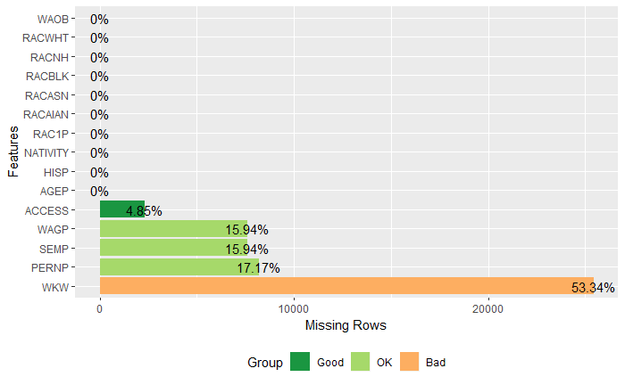

## 3.4 Brief of “Age Dispersion”

```r
base %>% select(AGEP) %>%  summary()
```

```
      AGEP
 Min.   : 0.00
 1st Qu.:22.00
 Median :44.00
 Mean   :42.54
 3rd Qu.:62.00
 Max.   :93.00
```

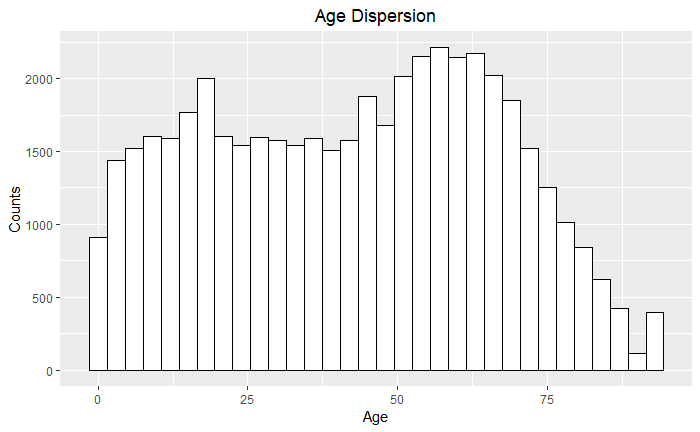

```r
base %>% ggplot(aes(AGEP)) + geom_histogram(binwidth = 3, fill = "white", colour = "black") + xlab("Age") + ylab("Counts") + ggtitle("Age Dispersion") + theme(plot.title = element_text(hjust = 0.5))
```

## 3.5 Brief of “Wage”

**- Summary of wages - Overall**

```r
summary(base$WAGP)
```

```
   Min. 1st Qu.  Median    Mean 3rd Qu.    Max.    NA's
      0       0    1800   21782   31200  356000    7597
```

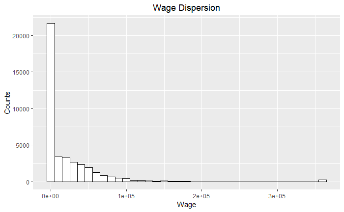

```r
base %>% ggplot(aes(WAGP)) + geom_histogram(binwidth = 10000, fill = "white", colour = "black") + xlab("Wage") + ylab("Counts") + ggtitle("Wage Dispersion") + theme(plot.title = element_text(hjust = 0.5))
```

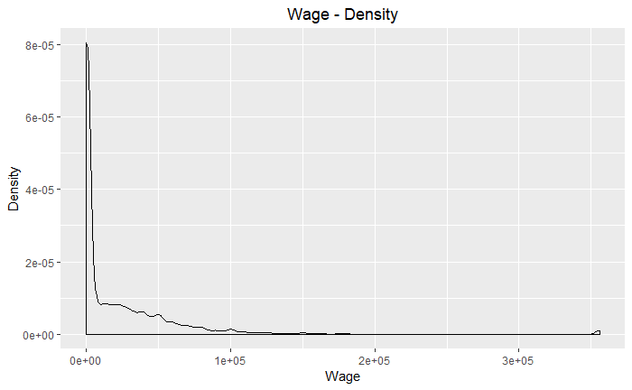

```r
base  %>% ggplot(aes(x = WAGP)) + geom_density() + xlab("Wage") +ylab("Density") + ggtitle("Wage - Density") + theme(plot.title = element_text(hjust = 0.5))
```

**- Summary of wages - By races**

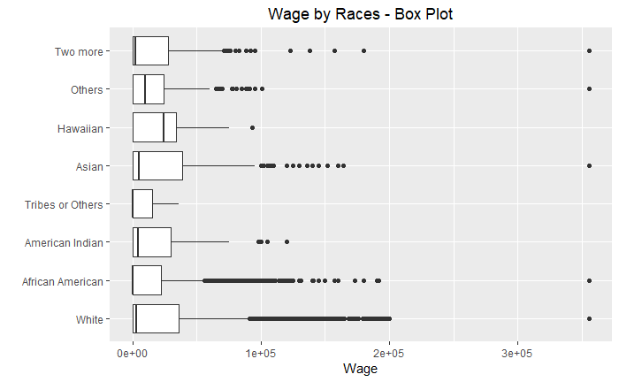

```r
ggplot(data = base, aes(x = RAC1P, y = WAGP)) + geom_boxplot() + coord_flip() + xlab("") + ylab("Wage") + ggtitle("Wage by Races - Box Plot") + theme(plot.title = element_text(hjust = 0.5))
```

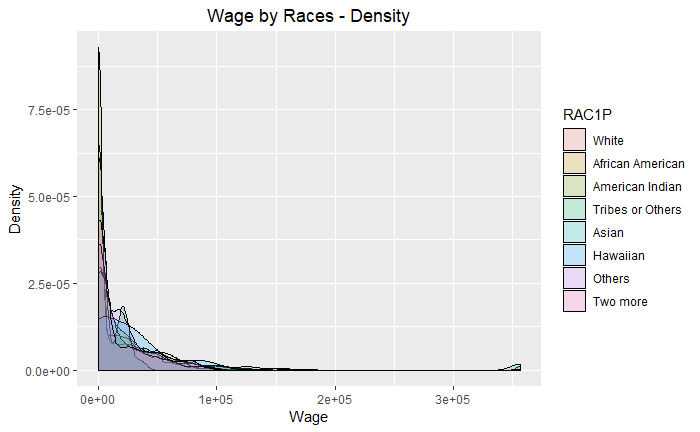

```r
ggplot(data = base, aes(x = WAGP, fill = RAC1P)) + geom_density(alpha = .2) + xlab("Wage") + ylab("Density") + ggtitle("Wage by Races - Density") + theme(plot.title = element_text(hjust = 0.5))
```

**Note:**

| category in the graphs above | corresponding title in the survey |
| --- | --- |
| Two more | Two or More Races |
| Others | Some Other Race alone |
| Hawaiian | Native Hawaiian and Other Pacific Islander alone |
| Asian | Asian alone |
| Tribes or Others | American Indian and Alaska Native tribes specified; or American Indian or Alaska Native, not specified and no other races |
| American Indian | American Indian alone |
| African American | Black or African American alone |
| White | White alone |

## 3.6 Brief of “Access to Internet”

**- Summary of access to internet**

Most of people pay for the internet access.

```
Paid Access Free Access   No Access        NA's
      36959        1202        7186        2312
```

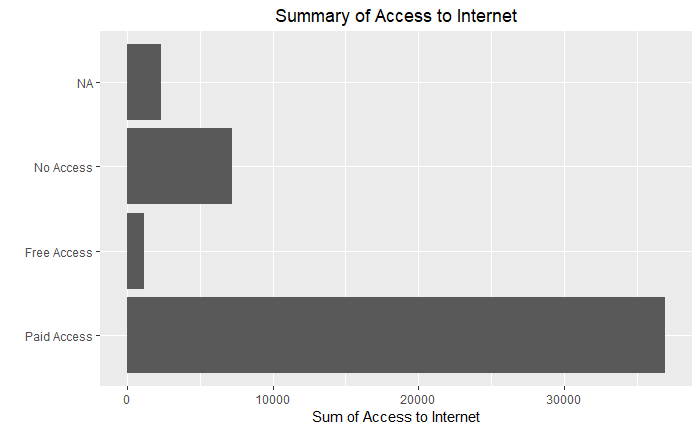

```r
ggplot(data = base, aes(x = ACCESS)) + geom_bar() + xlab("") + ylab("Sum of Access to Internet") + coord_flip() + ggtitle("Summary of Access to Internet") + theme(plot.title = element_text(hjust = 0.5))
```

**- Summary of access to internet by races**

**Internet access by counts of each race group**

When counting the absolute number of each category type of internet access, the race groups of “White” and “African American” count the most in all access type. The reason could be that the race groups of white and african american is the demographic majority in the overall population.

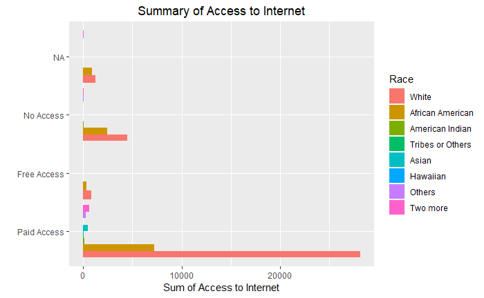

```r
ggplot(data = base2, aes(x = ACCESS, y = counts, fill = RAC1P)) + geom_col(position = "dodge") + coord_flip() + xlab("") + ylab("Sum of Access to Internet")  + ggtitle("Summary of Access to Internet") + theme(plot.title = element_text(hjust = 0.5)) + labs(fill = "Race")
```

**Internet access by ratio in each race group**

The diagram below reveals that, in term of proportion within each group, (1) no “Free Access” in the Hawaiian group. This group has the highest ratio of paied internet service; (2) Asian group does not like “Free Access” as well, and second in the category of paid access; (3) the group of “African American” and “Others” have a lower rate in paid access and a higher rate in NO access to internet, but this two group share the most resource of free internet access.

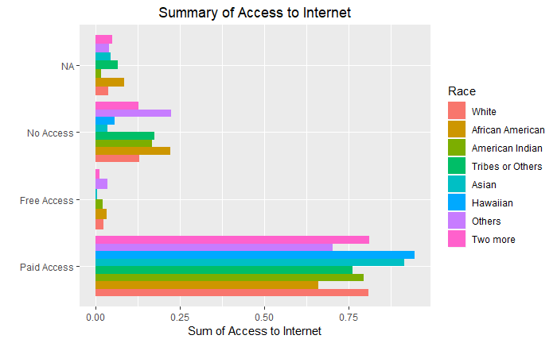

```r
ggplot(data = base4, aes(x = ACCESS, y = rate, fill = RAC1P)) + geom_col(position = "dodge") + coord_flip() + xlab("") + ylab("Sum of Access to Internet")  + ggtitle("Summary of Access to Internet") + theme(plot.title = element_text(hjust = 0.5)) + labs(fill = "Race")
```

```r
rm("base3","base4", "base2")
```

# 4. Criteria for filtering the data

**1. Age range:**

The ages of cases covered in the survey are ranging from **0 year old to 93 years old**. There is **no missing value** under the age category.

According to the regulation from US Department of Labor, the legal working age is 14 (for most non-agricultural work), and the early retirement age is 62. This study will looks at the **age group of 14~62 years old (Data Filtering Criteria 1)**.

```r
base <- base %>%
        mutate( age_group = case_when(
                            AGEP < 14 ~ "Other ages (exclude)",
                            AGEP >= 14 & AGEP <= 62 ~ "Age 14-62 (include)",
                            AGEP > 62 ~ "Other ages (exclude)"
        ))
base$age_group <- as.factor(base$age_group)
```

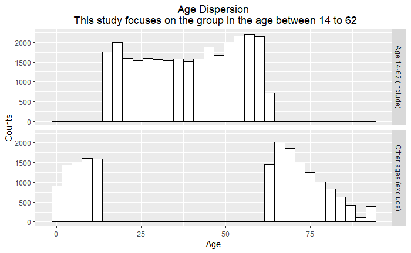

```r
base %>% ggplot(aes(AGEP)) + geom_histogram(binwidth = 3, fill = "white", colour = "black") + xlab("Age") + ylab("Counts") + ggtitle("Age Dispersion\n This study focuses on the group in the age between 14 to 62") + theme(plot.title = element_text(hjust = 0.5)) + facet_grid(age_group ~ .)
```

Remove the records which are out of the age group of 14 to 62.

```r
base <- base %>%  filter(AGEP>=14 & AGEP <= 62)
base$age_group <- NULL
```

**2. Wage:**

This study excludes the out-liers of super rich and upper level, which do not contribute to the discussion of premium from access to internet. Considering the hourly wage in US was $7.25 back to 2014 and this study considering people working more than 40 weeks as the full time employees, this minimum income for full-time emloyees would be 7.25 USD/Hour * 40 Weeks * 40 Hours/Week = 11600 USD. **Yearly wage from 11,600 up to the third quartile(54,000) will be included in this study (Data Filtering Criteria 2)**. The miss data and rests will be removed.

```r
base <- base %>%  filter(WAGP<54000 & WAGP > 11600)
```

**3. Tolerance for missing data:**

The tolerance for missing date varies by research topic. The tolerance for missing data in this study is arbitrarily set at 50% - **the missing records in a variable should not be more than half of the total observations (Data Filtering Criteria 3)**.

- re-exam missing data after filtering data based on the **Criteria 1** and **Criteria 2**.

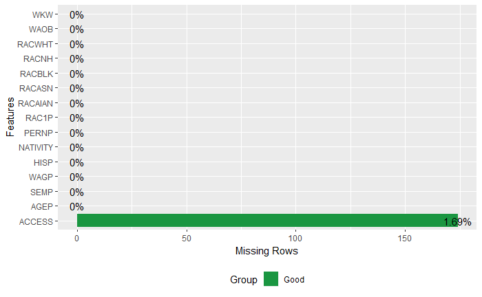

```r
plot_missing(base)
```

- Based on the graph above, all variables follow the Creditera 3.

**4. Annually Working Weeks:**

The selection of full time employee is arbitrary. This study includes groups which **work more than 40 weeks a years (Data Filtering Criteria 4)**. (Please be noted: More studies shold be considered in decideing the threshold separating full-time and part-time employee. This study set the 40 week/year as the threshold for now.)

```r
base <- base %>%
         filter(WKW %in% c("50 to 52 weeks worked during past 12 months", "48 to 49 weeks worked during past 12 months", "40 to 47 weeks worked during past 12 months"))
```

# 5. Data summary - After the restriction

```
      AGEP            SEMP             WAGP                                      HISP              NATIVITY        PERNP
 Min.   :16.00   Min.   : -6800   Min.   :11700   Not Spanish/Hispanic/Latino      :9287   Native      :9240   Min.   :  5600
 1st Qu.:30.00   1st Qu.:     0   1st Qu.:20600   Mexican                          : 200   Foreign born: 377   1st Qu.: 20800
 Median :41.00   Median :     0   Median :30000   Guatemalan                       :  29                       Median : 30000
 Mean   :40.87   Mean   :   378   Mean   :30888   Puerto Rican                     :  26                       Mean   : 31266
 3rd Qu.:51.00   3rd Qu.:     0   3rd Qu.:40000   All Other Spanish/Hispanic/Latino:  18                       3rd Qu.: 40000
 Max.   :62.00   Max.   :266000   Max.   :53000   Salvadoran                       :   8                       Max.   :316000
                                                  (Other)                          :  49
              RAC1P      RACAIAN    RACASN     RACBLK     RACNH      RACWHT                                         WAOB
 White           :6973   No :9523   No :9486   No :7319   No :9615   No :2549   US state (POB = 001-059)              :9153
 African American:2261   Yes:  94   Yes: 131   Yes:2298   Yes:   2   Yes:7068   Latin America (POB = 303,310-399)     : 237
 Others          : 121                                                          Asia (POB = 158-159,161,200-299)      : 119
 Two more        : 104                                                          Europe (POB = 100-157,160,162-199)    :  72
 Asian           : 103                                                          Africa (POB = 400-499)                :  12
 American Indian :  41                                                          PR and US Island Areas (POB = 060-099):  11
 (Other)         :  14                                                          (Other)                               :  13
                                              WKW               ACCESS
 50 to 52 weeks worked during past 12 months    :8884   Paid Access:8310
 48 to 49 weeks worked during past 12 months    : 193   Free Access: 250
 40 to 47 weeks worked during past 12 months    : 540   No Access  : 948
 27 to 39 weeks worked during past 12 months    :   0   NA's       : 109
 14 to 26 weeks worked during past 12 months    :   0
 less than 14 weeks worked during past 12 months:   0
```

==================

# 6. Building Models

## 6.1 Examine access to the internet and its relation to earnings.

```r
base %>% select(ACCESS) %>% summary()
```

```
         ACCESS
 Paid Access:8310
 Free Access: 250
 No Access  : 948
 NA's       : 109
```

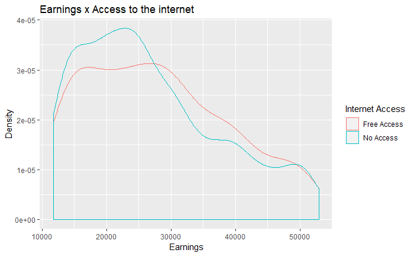

```r
base %>%  filter(!is.na(ACCESS) & ACCESS != "Paid Access") %>%
  ggplot(aes(WAGP,color=ACCESS)) + geom_density() +
  labs(title="Earnings x Access to the internet",
       x ="Earnings", y = "Density") +
  scale_color_discrete(name="Internet Access",
                      labels=c("Free Access", "No Access"))
```

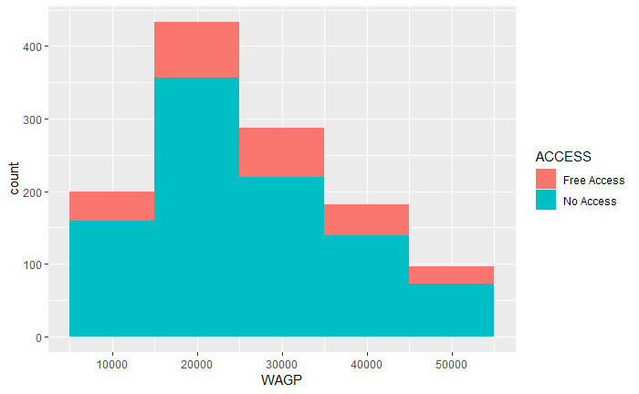

```r
base %>%  filter(!is.na(ACCESS) & ACCESS != "Paid Access") %>%
  ggplot() + geom_histogram(aes(x=WAGP,fill=ACCESS), binwidth = 10000)
```

```r
base %>%
  filter(!is.na(ACCESS) & ACCESS != "Paid Access") %>%
  group_by(ACCESS, RAC1P) %>%
  summarise (mean(WAGP),sd(WAGP),min(WAGP),max(WAGP), median(WAGP))
```

| ACCESS | RAC1P | mean(WAGP) | sd(WAGP) | min(WAGP) | max(WAGP) | median(WAGP) |
| --- | --- | --- | --- | --- | --- | --- |
| Free Access | White | 28350.92 | 10824.968 | 12000 | 52000 | 28000 |
| Free Access | African American | 28240.74 | 11231.293 | 11700 | 52000 | 25000 |
| Free Access | American Indian | 18800.00 | NaN | 18800 | 18800 | 18800 |
| Free Access | Others | 31000.00 | 26870.058 | 12000 | 50000 | 31000 |
| Free Access | Two more | 13666.67 | 1527.525 | 12000 | 15000 | 14000 |
| No Access | White | 28489.07 | 11033.888 | 11800 | 53000 | 26000 |
| No Access | African American | 24930.72 | 10344.866 | 11700 | 52000 | 23000 |
| No Access | American Indian | 23266.67 | 2052.641 | 21000 | 25000 | 23800 |
| No Access | Tribes or Others | 20000.00 | NaN | 20000 | 20000 | 20000 |
| No Access | Asian | 28500.00 | 12020.815 | 20000 | 37000 | 28500 |

[output cut: 2 more lines]

## 6.2 Race and access to the internet

```r
base %>% select(RAC1P) %>% summary()
```

```
              RAC1P
 White           :6973
 African American:2261
 Others          : 121
 Two more        : 104
 Asian           : 103
 American Indian :  41
 (Other)         :  14
```

```r
base %>% filter(ACCESS=="No Access") %>% select(RAC1P) %>% summary() #person doesn't have ACCESS to Internet
```

```
              RAC1P
 White           :558
 African American:345
 Others          : 28
 Two more        : 11
 American Indian :  3
 Asian           :  2
 (Other)         :  1
```

[figure not shown]

```r
base %>%  filter(!is.na(ACCESS) & ACCESS != "Paid Access") %>%
  ggplot() + geom_bar(aes(x = RAC1P, fill=ACCESS)) +
  coord_flip() +
  xlab('Race') +
  scale_x_discrete(labels = c('White', 'Black', 'Native American', "Multiple tribes", "Asian", 'Pacific Islander', 'Other', 'Two or more Races')) +
  theme(legend.position= c(0.87,0.85))
```

**Building the model**

```r
base_model <- base %>%
  filter(!is.na(ACCESS) & ACCESS != "Paid Access") %>%
  mutate(free_access = ACCESS == "Free Access",
         hispanic = HISP != "Not Spanish/Hispanic/Latino",
         black = RACBLK == "Yes"
         )

model_01 <- lm(WAGP ~ free_access, data = base_model)
model_01 %>% summary()
```

```
Call:
lm(formula = WAGP ~ free_access, data = base_model)

Residuals:
   Min     1Q Median     3Q    Max
-16422  -8879  -1951   7049  26049

Coefficients:
                Estimate Std. Error t value Pr(>|t|)
(Intercept)      26950.8      354.7  75.972   <2e-16 ***
free_accessTRUE   1171.2      776.6   1.508    0.132
---
Signif. codes:  0 ‘***’ 0.001 ‘**’ 0.01 ‘*’ 0.05 ‘.’ 0.1 ‘ ’ 1

Residual standard error: 10920 on 1196 degrees of freedom
Multiple R-squared:  0.001898,  Adjusted R-squared:  0.001064
F-statistic: 2.274 on 1 and 1196 DF,  p-value: 0.1318
```

```r
model_02 <- lm(WAGP ~ free_access + hispanic + black, data = base_model)
model_02 %>% summary()
```

```
Call:
lm(formula = WAGP ~ free_access + hispanic + black, data = base_model)

Residuals:
   Min     1Q Median     3Q    Max
-17199  -8348  -2194   6764  27008

Coefficients:
                Estimate Std. Error t value Pr(>|t|)
(Intercept)      28347.5      443.1  63.978  < 2e-16 ***
free_accessTRUE    851.9      770.8   1.105 0.269271
hispanicTRUE     -5355.2     1456.9  -3.676 0.000248 ***
blackTRUE        -2958.3      661.2  -4.474 8.39e-06 ***
---
Signif. codes:  0 ‘***’ 0.001 ‘**’ 0.01 ‘*’ 0.05 ‘.’ 0.1 ‘ ’ 1

Residual standard error: 10800 on 1194 degrees of freedom
Multiple R-squared:  0.02529,   Adjusted R-squared:  0.02284
F-statistic: 10.33 on 3 and 1194 DF,  p-value: 1.031e-06
```

# 7. Updates for the week3

**The updates in the week3’s report are:**

1. Reframe the structure of the report. The main structure of the report is (1) Research Qestion and Variable -> (2) Data Cleaning -> (3) EDA -> (4) criterion and data filtering -> (5) Model.
2. Impove the EDA and data cleaning, debug code.
3. Following the professor’s comments from week2 and group’s new thoughts to revise the criteria of **working weeksage** - now it is 40 weeks and above; **age** - now it is 14-62; and **wage** - now it is $11600 - $54000
4. Build the models as in the section 6 above. (From the model 1 above, no conclusion can be drawn from the model 1 that the free internet access relates to the wage - the p-value is 0.132. In the model 2 above, the race factor, such as “hispanic” or “black”, relates to the wage at significant level 0, the Multiple R-squared value of this model is only at 2.53%.) - Since no meaningful conclusion can be drawn from the two models above, the team halt at this moment, and will ask for help from professor review the model/solution in the next class.